# Supplementary Information

Andrew Ghazi

6/21/2017

Throughout this document you can click the `Code` buttons to see the code blocks that generated the displayed output.

## S1 - MPRA diagram

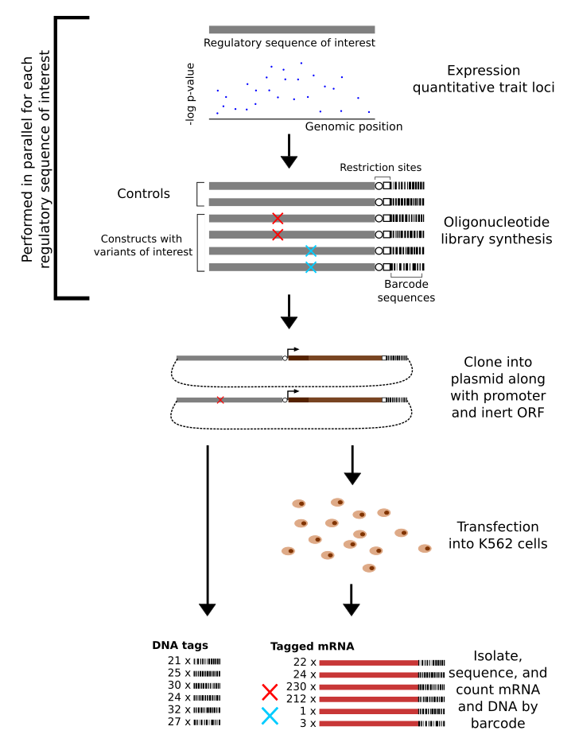

## S2 - MPRA Activity Variance

Let’s visualize the variance of MPRA activity measurements. We do this by computing the activity of each barcode for an allele, then taking the standard deviation of those activities. Repeating this for all alleles, we can see what the distribution of standard deviations are across alleles.

### S2.1 - MPRA Activity Variance in Tewhey et al., Cell 2016

Let’s begin with Tewhey et al., Cell 2016. The study’s data was acquired through direct correspondence with the authors. We compute the activity of each barcode in each transfection. Then, for every allele in every transfection, we compute the standard deviation of the activities. We then produce a histogram of the standard deviations in each transfection.

```r
library(tidyverse)
library(magrittr)
library(parallel)
library(knitr)
library(nortest)
```

```r
dir = '/mnt/bigData2/andrew/MPRA/Tewhey/indivTags/'

files = list.files(dir,
                   pattern = '.expanded$')

getFileDepth = function(file){
  # function to get the total number of reads in a sample. Used to normalize counts by sample depth.

  read_tsv(paste0(dir, file),
           col_names = c('allele', 'barcode', 'count')) %>%
    .$count %>%
    sum
}

#apply the above function to the sample files
fileDepths = data_frame(src = files,
                        fileDepth = mclapply(src,
                                             getFileDepth,
                                             mc.cores = 19) %>% unlist)
```

A few example DNA barcode counts by sample file:

```r
dnaCounts = map(1:5, ~read_tsv(paste0(dir, files[.x]),
                               col_names = c('allele', 'barcode', 'count')) %>%
                  mutate(src = files[.x])) %>%
  reduce(bind_rows)

dnaCounts %>% # show a random sample of the counts
  sample_n(5) %>%
  kable

dnaCounts %<>%
  left_join(fileDepths, by = 'src') %>%
  mutate(depthAdjCount = 1e6*count/fileDepth)

depthAdjDNAmeanCount = dnaCounts %>%
  group_by(barcode) %>%
  summarise(allele = allele[1],
            bcMean = mean(depthAdjCount)) %>%
  ungroup
#grouping together the huge number of barcodes takes a while, so this is saved and loaded

save(dnaCounts, file = '~/designMPRA/outputs/tewheyDNAcounts.RData')
save(depthAdjDNAmeanCount, file = '~/designMPRA/outputs/tewheyDepthAdjDNAcounts.RData')
```

| Allele | Barcode | Count | Transfection File Name |
| --- | --- | --- | --- |
| rs150694950_B | AGGATTTTACACCGATTTTA | 1 | Geuv_90K_ctrl.r5.tag.ct.indiv.expanded |
| rs12168499_RC_A | TGGCTACTCCGTAACGTGAA | 26 | Geuv_90K_ctrl.r3.tag.ct.indiv.expanded |
| rs3211362_RC_A | ACGACGACATTGGGGTACTT | 2 | Geuv_90K_ctrl.r5.tag.ct.indiv.expanded |
| rs117915926_B | GGGGGTGCGTTTCGATAAAT | 3 | Geuv_90K_ctrl.r1.tag.ct.indiv.expanded |
| rs4803987_RC_B | GGCTTCCCTCGAATTGTACC | 12 | Geuv_90K_ctrl.r5.tag.ct.indiv.expanded |

So to get the DNA normalization factor we simply take the mean of the DNA counts across the DNA transfections. For example:

```r
depthAdjDNAmeanCount %>%
  head %>%
  set_names(c('Barcode', 'Allele', 'Mean Depth Adjusted DNA Count')) %>%
  kable
```

| Barcode | Allele | Mean Depth Adjusted DNA Count |
| --- | --- | --- |
| AAAAAAAAAAAACCAAGCGG | rs116221068_B | 0.0835755 |
| AAAAAAAAAAAACGTACTTC | rs9977746_B | 0.0245955 |
| AAAAAAAAAAAATGGCTCAC | rs6051692_RC_A | 0.0228665 |
| AAAAAAAAAAAATTCCACGT | rs2915876_RC_A | 0.0628202 |
| AAAAAAAAAAACAAAAGTCC | rs2234161_B | 0.2756719 |
| AAAAAAAAAAACAGTGTTTT | rs59955136_A | 0.2367092 |

So for example the first barcode for allele rs116221068_B was counted 0.0835755 times on average across the plasmid sequencing runs (after adjusting for depth). The depth adjustment is performed as follows:
$$10^6 * \frac{count}{sum\:of\:barcode\:counts\:in\:sequencing\:run}$$

This normalizes each observed count according to how deeply the replicate was sequenced.

Tewhey et al., Cell 2016 had five plasmid replicates, so the estimates of the mean DNA counts from this study will likely be more precise than the counterparts in Ulirsch et al., Cell 2016 which had only two plasmid replicates. This will in turn make the downstream activity measurements more stable, thus the activity standard deviations in this paper will likely be lower.

We cut out barcodes that were not well represented in the DNA samples. A (log-scale) density plot of the mean depth-normalized count shows that .06 (shown as a dotted vertical line) would be a good cutoff. This cuts out 4221460 out of 19611641 barcodes. The first few modes represents failed barcodes with very low counts while the large mode represents well-performing barcodes (for further example see Ulirsch et al., Cell 2016 Figure 1B):

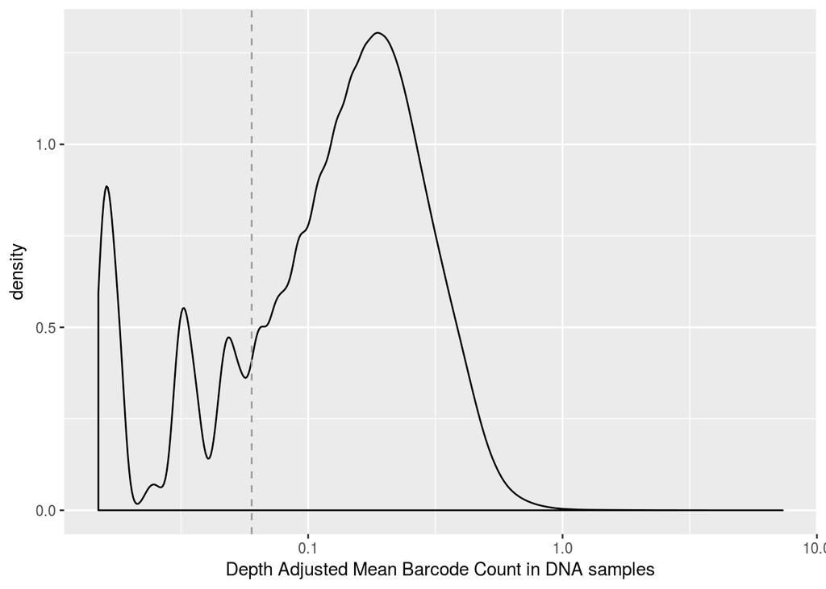

```r
depthAdjDNAmeanCount %>%
  ggplot(aes(bcMean)) +
  geom_density(adjust = 2) +
  scale_x_log10() +
  geom_vline(xintercept = .06,
             lty = 2,
             color = 'grey60') +
  xlab('Depth Adjusted Mean Barcode Count in DNA samples')
```

Then we compute the activity levels of each barcode by taking the depth adjusted count from an RNA sequencing run, dividing through the depth adjusted mean count from the DNA runs, then taking the log:

```r
library(parallel)
library(nortest) # for lillie.test()

# For a given data file
computeTransfectionStatistics = function(fileNum){
  # Get the file's depth normalization factor
  depthNum = fileDepths %>% filter(src == files[fileNum]) %>% .$fileDepth

  # Read in the counts
  rnaCounts = read_tsv(paste0(dir, files[fileNum]),
                       col_names = c('allele', 'barcode', 'count')) %>%
    mutate(depthAdjCount = 1e6*count/depthNum) #normalize them for depth

  # Then compute statistics for the file
  alleleStatistics = depthAdjDNAmeanCount %>%
    filter(bcMean > .06) %>% # this is where we introduce the cutoff from the previous section
    left_join(rnaCounts, by = c('allele', 'barcode')) %>% #join onto DNA counts
    mutate(activity = log(depthAdjCount/bcMean)) %>% #compute activity
    group_by(allele) %>% #for each allele
    summarise(alleleMean = mean(activity, na.rm = TRUE), #compute several statistics
              alleleSD = sd(activity, na.rm = TRUE),
              numBarcodes = sum(!is.na(count)),
              lillieforsP = ifelse(numBarcodes > 4, lillie.test(na.omit(activity))$p.value, NA)) %>%
    filter(numBarcodes > 1) %>% # take only alleles which had > 1 barcode representatives
    mutate(file = files[fileNum]) # and add on a file identifier
   # The filter removes alleles that only had zero or one barcodes show up in
   # the RNA, for which a standard deviation is not meaningful

  return(alleleStatistics)
}

#apply the above function to the RNA data files
transfectionStatistics = mclapply(6:19,
                                  computeTransfectionStatistics,
                                  mc.cores = 14)

# Join the results together and clean up the file names
allTransfectionsStats = transfectionStatistics %>%
  reduce(bind_rows) %>%
  mutate(file = gsub('Geuv_90K_', '', file) %>% gsub('.tag.ct.indiv.expanded', '', .))
save(allTransfectionsStats, file = '~/designMPRA/outputs/tewheyAllTransfectionsStats.RData')
```

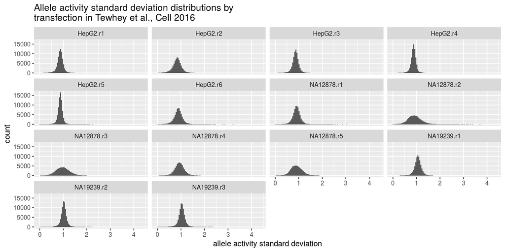

```r
allTransfectionsStats %>%
  ggplot(aes(alleleSD)) +
  geom_histogram(bins = 100) +
  facet_wrap('file') +
  xlab('allele activity standard deviation') +
  ggtitle('Allele activity standard deviation distributions by\ntransfection in Tewhey et al., Cell 2016')
```

We can look at the activity distribution of the two alleles for a single SNP tested. We’ll take `rs1674999` as an example. A random sample of the raw counts:

```r
# counts = map(1:19, ~read_tsv(paste0(dir, files[.x]),
#                                col_names = c('allele', 'barcode', 'count')) %>%
#                   mutate(src = files[.x])) %>%
#   reduce(bind_rows)
#
# rs1674999counts = counts %>% filter(grepl('rs1674999', allele))

load('~/designMPRA/outputs/tewheyrs1674999counts.RData')

rs1674999counts %>%
  set_names(c('Allele', 'Barcode', 'Count', 'Transfection File Name')) %>%
  sample_n(5) %>%
  kable
```

| Allele | Barcode | Count | Transfection File Name |
| --- | --- | --- | --- |
| rs1674999_B | CATTTCTATCTTGCGCCAGT | 1 | Geuv_90K_ctrl.r5.tag.ct.indiv.expanded |
| rs1674999_A | TAAACCACGCCACTTGGAAC | 13 | Geuv_90K_NA19239.r2.tag.ct.indiv.expanded |
| rs1674999_B | CCAATACCATAGATGCCGTT | 6 | Geuv_90K_HepG2.r3.tag.ct.indiv.expanded |
| rs1674999_A | CATAGAGATCCCACCTAACG | 2 | Geuv_90K_NA19239.r2.tag.ct.indiv.expanded |
| rs1674999_A | AGCCTTCGACCGGTCAGTGG | 7 | Geuv_90K_ctrl.r4.tag.ct.indiv.expanded |

And a plot of the activity levels of all barcodes in all samples:

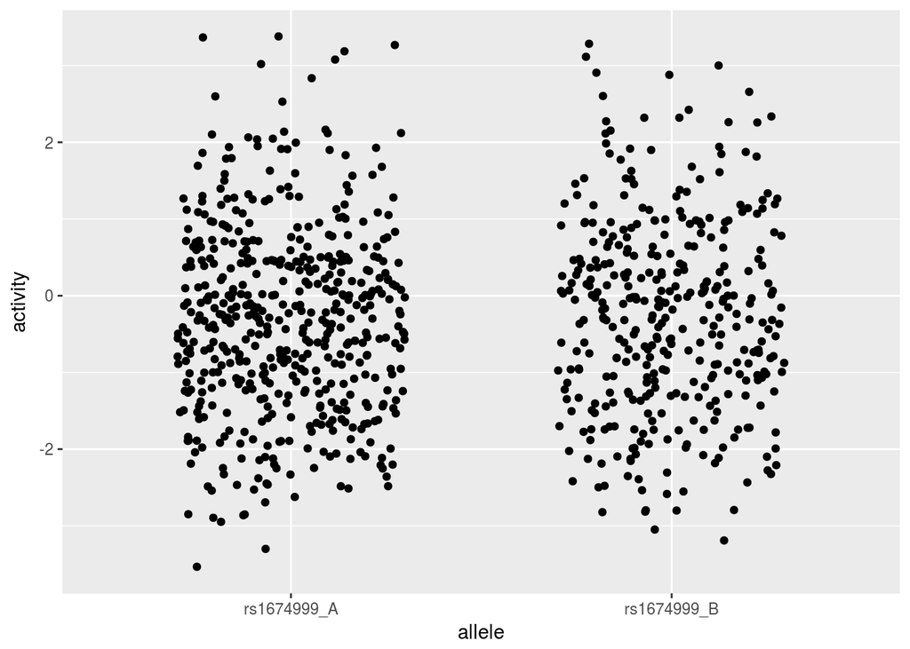

```r
assureRNAandDNA = function(barcodeDat){any(grepl('ctrl', barcodeDat$src))&any(grepl('HepG2|NA[0-9]{5}', barcodeDat$src))}

rs1674999counts %>%
  group_by(barcode) %>%
  nest %>%
  filter(map_lgl(data, assureRNAandDNA)) %>% #only include barcodes with DNA & RNA measurements
  unnest %>%
  left_join(fileDepths, by = 'src') %>%
  mutate(depthAdjCount = count*1e6/fileDepth) %>% #adjust count for sample depth
  group_by(barcode) %>% nest %>%
  mutate(ctrlMean = map_dbl(data, ~filter(.x, grepl('ctrl', .x$src))$depthAdjCount %>% mean)) %>% # take mean count of control samples
  unnest %>%
  filter(!grepl('ctrl', src)) %>%
  mutate(activity = log(depthAdjCount / ctrlMean)) %>% #compute activity of RNA samples
  mutate(replicate = gsub('Geuv_90K_', '', src) %>% gsub('.tag.ct.indiv.expanded', '', .)) %>%
  ggplot(aes(allele, activity)) +
  geom_jitter(height = 0, width = .3)
```

This SNP doesn’t seem to have a large transcriptional shift between the alleles (both alleles have roughly the same average activity), but one can see that this level of activity variance (around 1.0, which is fairly common within the experiment as can be seen by the histograms of standard deviations above) is large. Keep in mind that the above plot aggregates the data from all 14 transfections. Detecting a low magnitude transcriptional shift (for example a 33% increase in mRNA per DNA corresponding to a TS of $log(1.33) = .285$) at 90% power at the significance level required to overcome multiple corrections would require an even larger number of data points than shown here. A power calculation with `pwr::pwr.t.test` shows this:

```r
library(pwr)

pwr.t.test(d = .285,
           sig.level = .05/39479, # bonferroni correction for the number of oligo pairs tested in the paper
           power = .9)
```

```
##
##      Two-sample t test power calculation
##
##               n = 930.0622
##               d = 0.285
##       sig.level = 1.266496e-06
##           power = 0.9
##     alternative = two.sided
##
## NOTE: n is number in *each* group
```

### S2.2 - MPRA Activity Variance in Ulirsch et al., Cell 2016

Repeating the analysis with a different study. This data was acquired from the [authors’ website](http://www.bloodgenes.org/RBC_MPRA/). The code differs slightly due to differences in how the data was provided by the authors, but the analysis is the same.

A few example barcode counts:

```r
dir = "/mnt/labhome/andrew/MPRA/paper_data/"

UMPRA = read_delim(file = paste0(dir, "Raw/", "RBC_MPRA_minP_raw.txt"),
                         delim = "\t",
                         col_names = T,
                         col_types = cols(chr = "c"))

UMPRA %>% # show a few example counts
  select(chr, pos, ref, alt, byallele, K562_minP_DNA1:K562_GATA1_minP_RNA4) %>%
  gather(key = src, value = count, K562_minP_DNA1:K562_GATA1_minP_RNA4) %>%
  sample_n(5) %>%
  set_names(c('Chrom', 'Position', 'Reference Allele', 'Alternate Allele', 'Allele ID', 'Transfection', 'Count')) %>%
  kable
```

| Chrom | Position | Reference Allele | Alternate Allele | Allele ID | Transfection | Count |
| --- | --- | --- | --- | --- | --- | --- |
| 6 | 109607369 | G | C | 6 109607369 1/3 Mut | K562_CTRL_minP_RNA4 | 125 |
| 22 | 21940189 | T | G | 22 21940189 2/3 Mut | K562_CTRL_minP_RNA3 | 27 |
| 19 | 33250690 | C | T | 19 33250690 1/3 Ref | K562_CTRL_minP_RNA5 | 14 |
| 4 | 122689245 | C | T | 4 122689245 1/2 Mut | K562_CTRL_minP_RNA1 | 18 |
| 10 | 46045315 | C | T | 10 46045315 1/2 Mut | K562_CTRL_minP_RNA2 | 10 |

Here we’ll use a mean depth-normalized DNA count of .13:

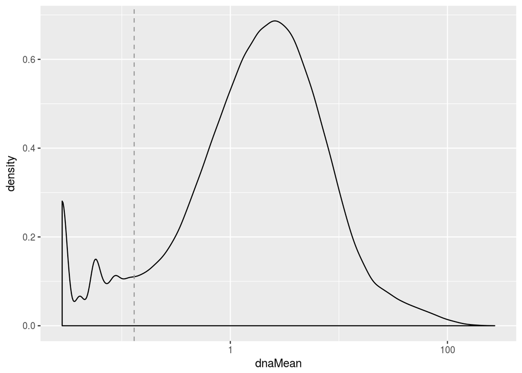

```r
depthNormalize = function(sampleCounts){
  sampleCounts*1e6/sum(sampleCounts)
}

UMPRA %>%
  mutate_at(vars(contains('K562')), depthNormalize) %>%
  mutate(dnaMean = (K562_minP_DNA1 + K562_minP_DNA2)/2) %>%
  ggplot(aes(dnaMean)) +
  geom_density() +
  scale_x_log10() +
  geom_vline(xintercept = .13,
             lty = 2,
             color = 'grey60')
```

And here are the distributions of allele activity standard deviations by sample:

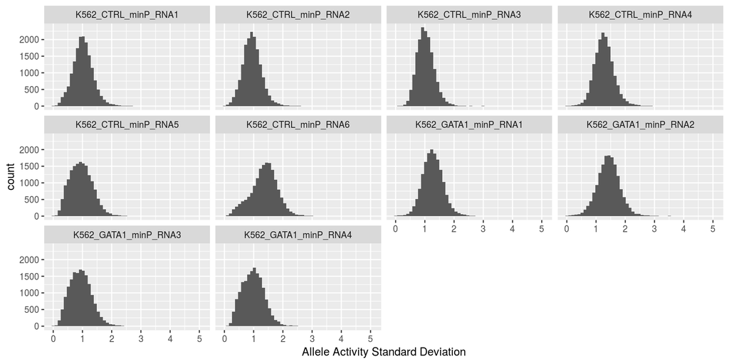

```r
activitySDs = UMPRA %>%
  mutate_at(vars(contains('K562')), depthNormalize) %>%
  mutate(dnaMean = (K562_minP_DNA1 + K562_minP_DNA2)/2) %>%
  filter(dnaMean > .13) %>%
  select(-K562_minP_DNA1, -K562_minP_DNA2) %>%
  gather(sample, depthAdjCount, K562_CTRL_minP_RNA1:K562_GATA1_minP_RNA4) %>%
  mutate(activity = log(depthAdjCount / dnaMean)) %>%
  group_by(byallele, sample) %>%
  summarise(alleleSD = sd(activity[is.finite(activity)], na.rm = TRUE)) %>%
  ungroup

activitySDs %>%
  ggplot(aes(alleleSD)) +
  geom_histogram(bins = 50) +
  facet_wrap('sample') +
  xlab('Allele Activity Standard Deviation')
```

If we combine both studies, we can see the typical range of activity standard deviations. The third output exponentiates the standard deviations, showing the corresponding standard fold-change in mRNA out to DNA in.

```r
bothStudies = c(allTransfectionsStats$alleleSD, #Tewhey et al.
                activitySDs$alleleSD) #Ulirsch et al.

#Mean activity standard deviation in both studies:
bothStudies %>%
  mean(na.rm = TRUE)
```

```
## [1] 0.9523771
```

```r
#Central 95% interval of activity standard deviations in both studies:
bothStudies %>%
  na.omit %>%
  quantile(c(.025, .975))
```

```
##      2.5%     97.5%
## 0.4531956 1.5874324
```

```r
#Central 95% interval of activity standard fold-change in both studies:
bothStudies %>%
  na.omit %>%
  quantile(c(.025, .975)) %>%
  exp
```

```
##     2.5%    97.5%
## 1.573332 4.891174
```

## S3 - Activity Normality Assumption

The “Power” tab of the application uses a t-test to estimate the power to detect functional variants with given activity variance across a range of transcriptional shifts.

Looking at the distribution of these p-values will tell us how commonly the normality assumption of our t-test holds. If all samples come from normal distributions, the p-values should follow a $Unif(0,1)$ distribution.

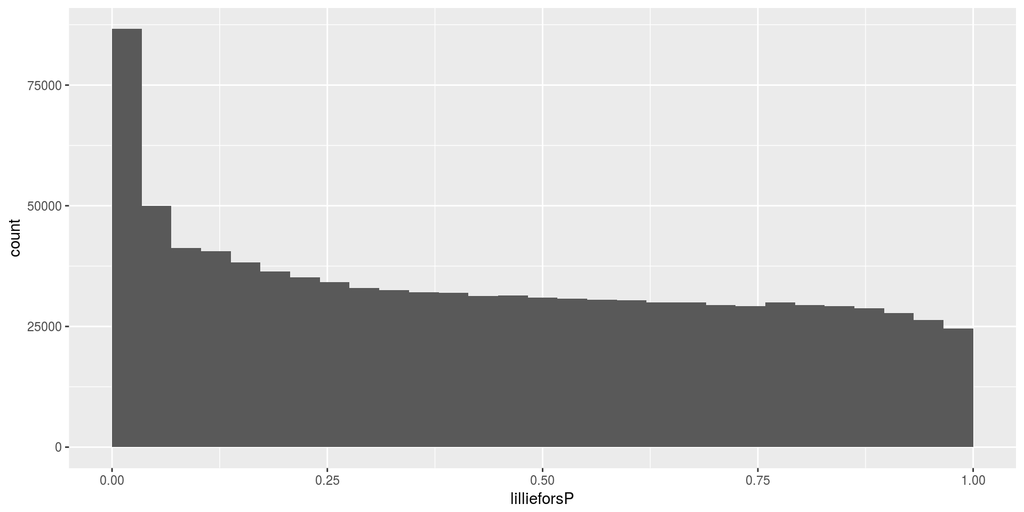

```r
allTransfectionsStats %>%
  na.omit() %>% #we returned NA for alleles with <4 observations
  ggplot(aes(lillieforsP)) +
  geom_histogram(breaks = seq(0,1,length.out = 30))
```

While a subset of the variants from Tewhey et al. clearly skew from the $Unif(0,1)$ distribution one would expect from normally distributed samples, the fraction of alleles that defy the expected pattern is relatively small. This suggests that a t-test should usually provide a reasonable approximation of the true power.

The highly non-normal alleles tend simply to come from alleles with the highest numbers of barcodes / barcode counts. There is no indication that SNPs with large transcriptional shifts (i.e. those we aim to detect with the assay) systematically defy the normality assumption. The following plot shows this with the observed transcriptional shift on the x-axis and p-value of a Lilliefors test on the activity measurements of the second allele on the y-axis (the plot for the first allele looks very similar). If the most important SNPs systematically defied the normality assumptions, the SNPs on the left and right sides would show the lowest p-values, which is not observed:

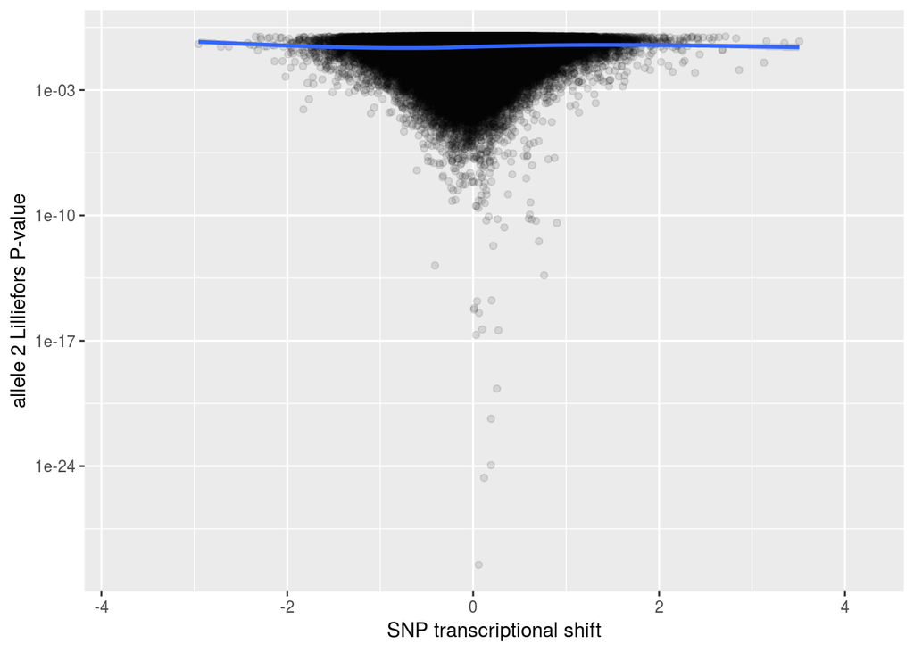

```r
shiftNonNormality = allTransfectionsStats %>%
  separate(allele, into = c('SNP', 'allele'), sep = '_(?=[AB]$)|_(?=alt[AB]$)') %>%
  separate(allele, into = c('alt', 'allele'), sep = '(?=[AB]$)') %>%
  unite(SNP, SNP:alt) %>%
  mutate(SNP = gsub('_$', '', SNP)) %>%
  unite(SNPfile, SNP, file) %>%
  group_by(SNPfile) %>%
  summarise(numAlleles = n(),
            TS = ifelse(numAlleles == 2, alleleMean[2] - alleleMean[1], NA),
            allele1Lilliefors = lillieforsP[1],
            allele2lilliefors = lillieforsP[2])

shiftNonNormality %>%
  ggplot(aes(TS, allele2lilliefors)) +
  geom_point(alpha = .1) +
  geom_smooth() +
  scale_y_log10() +
  xlab('SNP transcriptional shift') +
  ylab('allele 2 Lilliefors P-value')
```

Furthermore, t-tests are generally considered robust against minor violations of the normality assumption.

All of this together suggests that having a t-test underlie our power calculations would be reasonable. Researchers won’t know the activity variance their experimental setups will achieve nor the true transcriptional shifts of their variants *a priori* in any case. The “Power” tab of the application is meant to use a few assumptions in order to provide approximate power estimates that researchers can use as rough guidelines for their experiments.

## S4 - Power calculations

The power calculations are done with `pwr.t.test` from the R `pwr` package using the following R code:

```r
tibble::data_frame(meanDiff = seq(0,5, by = .05),
                   pwr = pwr.t.test(n = input$nbarcode*input$nBlock,
                                    d = meanDiff / input$sigma,
                                    sig.level = input$alpha / input$nsnp)$power)
```

This returns the power to detect a transcriptional shift across a range from zero to five using user inputs (denoted `input$inputName`) on:  
* the number of barcodes per allele  
* the number of transfection replicates (blocks)  
* the number of variants being tested (used for correcting the significance level to account for multiple testing)  
* the desired significance level  
* the assumed variance of activity measurements

This data frame is then plotted.

## S5 - Barcode design

We generated the set of all possible DNA 12-mers then screened these according to the design parameters in Melnikov et al., Nature Biotechnology 2012 intended to assure that the barcodes are inert. These involve the following parameters:  
* each nucleotide occurs at least once  
* no runs of single nucleotides greater than length 3  
* do not contain restriction sites for KpnI/XbaI + do not start with `TCT` (this creates a restriction site with XbaI with the preceding sequence)  
* they do not match any human miR seed sequences

This was done with the `generate12mers.R` script in the package (copied below; not run in the generation of this document).

```r
library(tcR)
library(Biostrings)
nucruns = vector(mode = 'character', length = 4) %>% DNAStringSet
ni = 1
for (i in 4) {
  for (j in c('A', 'G', 'T', 'C')) {
    nucruns[ni] = rep(j, i) %>% paste(collapse = '') %>% DNAStringSet
    ni = ni + 1
  }
}

twelvemers = generate.kmers(12) %>% DNAStringSet
cat(paste0('done generating 12mers at ', Sys.time()))

#tmp = twelvemers[sample.int(length(twelvemers), size = 10)]

#Each nucleotide occurs at least one
missingone = apply(alphabetFrequency(twelvemers)[,1:4], 1, function(x){any(x == 0)})
twelvemers = twelvemers[!missingone]
cat(paste0('done removing twelvemers missing a nucleotide at ', Sys.time()))


#Cut out those with nucleotide runs of 4 or more in a row
hasnucruns = vcountPDict(nucruns, twelvemers) %>% colSums
hasnucruns = hasnucruns > 0
twelvemers = twelvemers[!hasnucruns]
cat(paste0('done removing 12mers with runs of 4 or more at ', Sys.time()))

#Cut out those that start with TCT (creates an alternative digestion site for XbaI)
tctStart = subseq(twelvemers, 1, 3) == DNAString('TCT')
twelvemers = twelvemers[!tctStart]
cat(paste0('done removing 12mers starting with TCT at ', Sys.time()))

#Cut out those that match the miRNA seed sequences
#For now let's just use the human ones since there are fewer and it won't take as long
species = read.table('~/plateletMPRA/mirBaseSpecies.txt') %>% #isolated species names with cat mature.fa | grep '>' | cut -f 3,4 -d \  > mirBaseSpecies.txt
  as.tbl %>%
  transmute(name = paste(V1 %>% as.character, V2 %>% as.character)) #%>%
  #filter(!duplicated(name))
human = grepl('Homo sapiens', species$name)

allSeeds = readRNAStringSet('~/plateletMPRA/mature.fa')

seedSeqs = allSeeds %>% subseq(2,7) %>% DNAStringSet #%>% unique
humanSeedSeqs = seedSeqs[human] %>% unique
seedSeqs = allSeeds %>% subseq(2,7) %>% DNAStringSet %>% unique

haveSeedlist = vwhichPDict(humanSeedSeqs, twelvemers) #this takes ~40 minutes. All seeds takes ~1h45m
save(list = c('twelvemers', 'haveSeedlist', 'humanSeedSeqs'), file = '~/designMPRA/outputs/haveHumanRNAiSeeds.RData')
haveSeed = sapply(haveSeedlist, function(x){length(x) > 0})

twelvemers = twelvemers[!haveSeed]
cat(paste0('done removing those with mirSeeds at ', Sys.time()))

print(length(twelvemers))
save(twelvemers, file = '~/designMPRA/outputs/inertTwelveMers.RData')
```

## S6 - Tool workflow

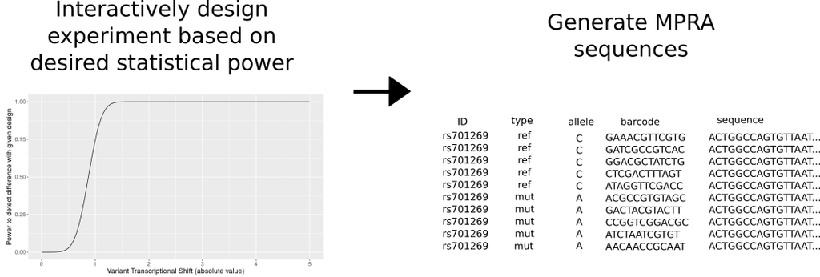